# DTF via Robust Scaling: Replication Code for Simulation 2

Author

Peter F Halpin

Published

August 6, 2026

# Initialization

```r
library(robustDIF)
library(dplyr)
library(tidyr)
library(ggplot2)
library(see)
library(mirt)

knitr::opts_chunk$set(fig.width = 11.5, fig.height = 5.4)

check_archive_robustDIF <- function(version = "0.2.0.20260708",
                                    archive.name = "Halpin2024-JEBS-archive") {
  installed_version <- as.character(utils::packageVersion("robustDIF"))
  if (installed_version != version) {
    stop(
      "This report expects robustDIF ", version,
      ", but found robustDIF ", installed_version,
      ". Install robustDIF from the Halpin2024-archive branch.",
      call. = FALSE)
  }

  desc <- utils::packageDescription("robustDIF")
  installed_archive <- desc[["Config/robustDIF/archive-name"]]
  if (!identical(installed_archive, archive.name)) {
    stop(
      "This report expects robustDIF archive '", archive.name,
      "', but found archive label '", installed_archive,
      "'. Install robustDIF from the Halpin2024-archive branch.",
      call. = FALSE)
  }
  invisible(installed_version)
}

check_archive_robustDIF()

find_results_dir <- function(candidates, pattern, min_files, label) {
  candidates <- unique(candidates)
  n_files <- vapply(
    candidates,
    function(path) {
      if (!dir.exists(path)) return(0L)
      length(list.files(path, pattern = pattern, full.names = TRUE))
    },
    integer(1))

  if (!any(n_files >= min_files)) {
    stop(
      "Could not find the ", label, " result files. Expected at least ",
      min_files, " files matching ", pattern, " in one of: ",
      paste(candidates, collapse = ", "),
      call. = FALSE)
  }

  normalizePath(candidates[which(n_files >= min_files)[1]], mustWork = TRUE)
}

sim2_pattern <- "^sim2_target_A.*_Di.*_ndif[0-9]+[.]rds$"
results_dir <- find_results_dir(
  c(
    "../results/sim2_target_delta",
    "results/sim2_target_delta",
    "../../paper/results/sim2_target_delta",
    "../../../paper/results/sim2_target_delta",
    "paper/results/sim2_target_delta"),
  pattern = sim2_pattern,
  min_files = 66L,
  label = "Simulation 2")

archive_root_candidates <- c("..", "replication")
archive_root <- archive_root_candidates[
  dir.exists(file.path(archive_root_candidates, "qmd")) &
    file.exists(file.path(archive_root_candidates, "README.md"))][1]
if (is.na(archive_root)) archive_root <- ".."

figure_dir <- file.path(archive_root, "figures/sim2_target_delta")
dir.create(figure_dir, recursive = TRUE, showWarnings = FALSE)

method_levels <- c("RDIF", "True")

method_cols <- c(
  "RDIF" = "#7BAFD4",
  "True" = "grey50")

alpha <- 0.05
ndif_levels <- seq(0, 20, by = 2)
p_dif_breaks <- seq(0, 1, by = 0.2)
target_levels <- c(0.25, 0.5)
slope_levels <- c(0.5, 1, 1.5)

mean_or_na <- function(x) {
  if (all(is.na(x))) NA_real_ else mean(x, na.rm = TRUE)
}

sd_or_na <- function(x) {
  if (sum(!is.na(x)) < 2) NA_real_ else sd(x, na.rm = TRUE)
}

breakdown_band <- function(data) {
  data |>
    distinct(target_Delta_i_public, slope_cell_public, target_Delta_i_num) |>
    mutate(
      xmin = 0.5 * n_items,
      xmax = Inf,
      ymin = -Inf,
      ymax = Inf)
}

ndif_x_scale <- function(data) {
  item_effect <- unique(data$target_Delta_i_num)
  if (length(item_effect) != 1L || is.na(item_effect)) {
    stop("Expected a single item-level effect size.", call. = FALSE)
  }

  n_dif_breaks <- seq(0, n_items, by = 4)
  true_delta_breaks <- n_dif_breaks * item_effect / n_items

  scale_x_continuous(
    breaks = n_dif_breaks,
    labels = n_dif_breaks,
    expand = expansion(add = c(0.8, 0.8)),
    sec.axis = sec_axis(
      ~ . * item_effect / n_items,
      breaks = true_delta_breaks,
      labels = sprintf("%.2f", true_delta_breaks),
      name = "True Delta"))
}

sim2_public_facets <- function(free_y = FALSE) {
  facet_wrap(
    vars(slope_cell_public),
    ncol = 3,
    scales = if (free_y) "free" else "free_x",
    axes = "all_x",
    axis.labels = "all_x")
}

plot_by_effect <- function(data, plot_fun, file_prefix = NULL,
                           width = 10, height = 4.8, dpi = 200) {
  effects <- levels(droplevels(data$target_Delta_i_public))
  plots <- vector("list", length(effects))
  names(plots) <- effects

  for (effect in effects) {
    plot_data <- data |>
      filter(target_Delta_i_public == effect) |>
      droplevels()

    plot <- plot_fun(plot_data) +
      labs(title = effect)

    print(plot)
    plots[[effect]] <- plot

    if (!is.null(file_prefix)) {
      file_effect <- gsub("[^A-Za-z0-9]+", "_", effect)
      file_effect <- gsub("^_|_$", "", file_effect)
      ggsave(
        file.path(figure_dir, paste0(file_prefix, "_", file_effect, ".png")),
        plot,
        width = width,
        height = height,
        dpi = dpi)
    }
  }

  invisible(plots)
}

public_plot_theme <- theme(
  panel.grid.minor = element_blank(),
  panel.spacing.x = grid::unit(1.2, "lines"),
  plot.margin = margin(t = 12, r = 8, b = 8, l = 8))

theme_set(theme_bw(base_size = 14))
```

# Run Sims

The production run was carried out condition-by-condition. Each condition was saved separately as an `.rds` file under `results/sim2_target_delta`, so the simulation can be restarted without overwriting completed conditions.

```bash
SIM2_TARGET_REPS=500 SIM2_TARGET_CORES=10 SIM2_TARGET_SEED=20260724 \
SIM2_TARGET_OVERWRITE=TRUE SIM2_TARGET_RUN_LABEL=production \
  Rscript run_sim2.R
```

The initial production run used `n.dif = 5` to include exactly 25 percent DIF items. We subsequently ran the missing `n.dif = 6` cells and use the even-count grid below for reporting.

```bash
SIM2_TARGET_REPS=500 SIM2_TARGET_CORES=10 SIM2_TARGET_SEED=20260724 \
SIM2_TARGET_OVERWRITE=FALSE SIM2_TARGET_RUN_LABEL=add_ndif6 \
  Rscript run_sim2.R
```

Simulation 2 uses 500 replications in each reported cell of a `3 x 2 x 11` grid:

- slope multiplier for true DIF items: `0.5`, `1`, `1.5`;
- target item-level effect size for true DIF items: `Delta_i = 0.25`, `0.50`;
- number of DIF items: `0`, `2`, `4`, …, `20`;
- total number of items: `20`;
- sample size per group: `500`;
- reference latent mean and variance fixed at `0` and `1`;
- comparison latent mean sampled from `U(-0.25, 0.25)`;
- comparison latent variance sampled from `U(0.5, 1.5)`.

For `n.dif > 0`, the group-2 slope is multiplied by the slope factor and the group-2 intercept is solved item-by-item so the true DIF items have the requested `Delta_i` on the `d_fun3` scale. For `n.dif = 0`, there are no DIF items; these cells provide the Type I error baseline.

The reported methods are `RDIF` and `True`, shown in alphabetical order. Here `RDIF` denotes the BH-start version of RDIF, and `True` denotes the oracle unit-weighted procedure using the known DIF pattern. The LRT and post-RDIF unit-weight procedures are omitted from this larger grid.

# Load Results

```r
sim_files <- list.files(
  results_dir,
  pattern = sim2_pattern,
  full.names = TRUE)

sim_list <- lapply(sim_files, readRDS)

sim_delta_all <- bind_rows(lapply(sim_list, `[[`, "delta")) |>
  mutate(
    method = factor(as.character(method), levels = method_levels),
    n_dif = as.integer(n_dif),
    n_items = as.integer(n_items),
    p_dif = n_dif / n_items,
    target_Delta_i_num = as.numeric(target_Delta_i),
    target_Delta_i = factor(
      target_Delta_i_num,
      levels = target_levels,
      labels = c("Delta_i = .25", "Delta_i = .50")),
    target_Delta_i_public = factor(
      target_Delta_i_num,
      levels = target_levels,
      labels = c("Item-Level Effect = 0.25", "Item-Level Effect = 0.50")),
    slope_multiplier = as.numeric(slope_multiplier),
    slope_cell = factor(
      paste0("A = ", slope_multiplier),
      levels = paste0("A = ", slope_levels)),
    slope_cell_public = factor(
      paste0("Slope Multiplier = ", slope_multiplier),
      levels = paste0("Slope Multiplier = ", slope_levels)),
    breakdown = p_dif >= 0.5)

sim_delta <- sim_delta_all |>
  filter(n_dif %in% ndif_levels)

sim_items_all <- bind_rows(lapply(sim_list, `[[`, "items")) |>
  mutate(
    method = factor(as.character(method), levels = method_levels),
    n_dif = as.integer(n_dif),
    n_items = as.integer(n_items),
    p_dif = n_dif / n_items,
    target_Delta_i_num = as.numeric(target_Delta_i),
    target_Delta_i = factor(
      target_Delta_i_num,
      levels = target_levels,
      labels = c("Delta_i = .25", "Delta_i = .50")),
    target_Delta_i_public = factor(
      target_Delta_i_num,
      levels = target_levels,
      labels = c("Item-Level Effect = 0.25", "Item-Level Effect = 0.50")),
    slope_multiplier = as.numeric(slope_multiplier),
    slope_cell = factor(
      paste0("A = ", slope_multiplier),
      levels = paste0("A = ", slope_levels)),
    slope_cell_public = factor(
      paste0("Slope Multiplier = ", slope_multiplier),
      levels = paste0("Slope Multiplier = ", slope_levels)),
    breakdown = p_dif >= 0.5)

sim_items <- sim_items_all |>
  filter(n_dif %in% ndif_levels)

run_info <- bind_rows(lapply(sim_list, function(x) {
  data.frame(
    n.reps = x$run$n.reps,
    n.cores = x$run$n.cores,
    base.seed = x$run$base.seed,
    condition.seed = x$run$condition.seed,
    save.mle = x$run$save.mle,
    save.fits = x$run$save.fits,
    completed = x$run$completed)
}))

status_files <- file.path(
  results_dir,
  c(
    "sim2_target_delta_status_production.csv",
    "sim2_target_delta_status_add_ndif6.csv"))
sim_status <- bind_rows(lapply(status_files[file.exists(status_files)], read.csv))

n_reps <- unique(sim_delta |>
  count(slope_multiplier, target_Delta_i, n_dif, method, name = "n") |>
  pull(n))
n_items <- unique(sim_delta$n_items)

stopifnot(nrow(distinct(sim_delta, slope_multiplier, target_Delta_i, n_dif)) == 66L)
```

# Item-Level Diagnostics

```r
item_diag <- sim_items |>
  mutate(flagged_bh = p_adjusted <= alpha) |>
  summarize(
    flagged_rate = mean(flagged_bh, na.rm = TRUE),
    mean_p = mean_or_na(p_value),
    mean_p_adjusted = mean_or_na(p_adjusted),
    mean_weight = mean_or_na(rdif_weight),
    mean_k = mean_or_na(k_i),
    true_Delta = mean_or_na(true_Delta),
    .by = c(
      slope_multiplier, slope_cell, slope_cell_public,
      target_Delta_i, target_Delta_i_num, target_Delta_i_public,
      n_dif, p_dif, true_dif)) |>
  mutate(
    diagnostic = ifelse(true_dif, "True positive rate", "False positive rate"))

knitr::kable(
  item_diag |>
    select(
      -target_Delta_i_num,
      -target_Delta_i_public,
      -slope_cell_public,
      -true_Delta),
  digits = 3)
```

| slope_multiplier | slope_cell | target_Delta_i | n_dif | p_dif | true_dif | flagged_rate | mean_p | mean_p_adjusted | mean_weight | mean_k | diagnostic |
| --- | --- | --- | --- | --- | --- | --- | --- | --- | --- | --- | --- |
| 0.5 | A = 0.5 | Delta_i = .25 | 0 | 0.0 | FALSE | 0.004 | 0.505 | 0.809 | 0.797 | 2.298 | False positive rate |
| 0.5 | A = 0.5 | Delta_i = .25 | 2 | 0.1 | FALSE | 0.007 | 0.502 | 0.781 | 0.789 | 2.273 | False positive rate |
| 0.5 | A = 0.5 | Delta_i = .25 | 2 | 0.1 | TRUE | 0.082 | 0.288 | 0.586 | 0.548 | 2.530 | True positive rate |
| 0.5 | A = 0.5 | Delta_i = .25 | 4 | 0.2 | FALSE | 0.009 | 0.503 | 0.760 | 0.782 | 2.255 | False positive rate |
| 0.5 | A = 0.5 | Delta_i = .25 | 4 | 0.2 | TRUE | 0.079 | 0.306 | 0.583 | 0.566 | 2.472 | True positive rate |
| 0.5 | A = 0.5 | Delta_i = .25 | 6 | 0.3 | TRUE | 0.078 | 0.327 | 0.582 | 0.581 | 2.423 | True positive rate |
| 0.5 | A = 0.5 | Delta_i = .25 | 6 | 0.3 | FALSE | 0.013 | 0.496 | 0.736 | 0.773 | 2.245 | False positive rate |
| 0.5 | A = 0.5 | Delta_i = .25 | 8 | 0.4 | TRUE | 0.072 | 0.353 | 0.586 | 0.603 | 2.374 | True positive rate |
| 0.5 | A = 0.5 | Delta_i = .25 | 8 | 0.4 | FALSE | 0.021 | 0.485 | 0.708 | 0.756 | 2.248 | False positive rate |
| 0.5 | A = 0.5 | Delta_i = .25 | 10 | 0.5 | FALSE | 0.041 | 0.444 | 0.661 | 0.712 | 2.285 | False positive rate |
| 0.5 | A = 0.5 | Delta_i = .25 | 10 | 0.5 | TRUE | 0.046 | 0.399 | 0.623 | 0.652 | 2.311 | True positive rate |
| 0.5 | A = 0.5 | Delta_i = .25 | 12 | 0.6 | TRUE | 0.035 | 0.446 | 0.663 | 0.697 | 2.265 | True positive rate |
| 0.5 | A = 0.5 | Delta_i = .25 | 12 | 0.6 | FALSE | 0.080 | 0.386 | 0.601 | 0.645 | 2.348 | False positive rate |
| 0.5 | A = 0.5 | Delta_i = .25 | 14 | 0.7 | FALSE | 0.089 | 0.342 | 0.574 | 0.604 | 2.413 | False positive rate |
| 0.5 | A = 0.5 | Delta_i = .25 | 14 | 0.7 | TRUE | 0.017 | 0.477 | 0.707 | 0.737 | 2.249 | True positive rate |
| 0.5 | A = 0.5 | Delta_i = .25 | 16 | 0.8 | TRUE | 0.010 | 0.502 | 0.754 | 0.770 | 2.250 | True positive rate |
| 0.5 | A = 0.5 | Delta_i = .25 | 16 | 0.8 | FALSE | 0.117 | 0.288 | 0.542 | 0.548 | 2.492 | False positive rate |
| 0.5 | A = 0.5 | Delta_i = .25 | 18 | 0.9 | TRUE | 0.005 | 0.500 | 0.772 | 0.775 | 2.268 | True positive rate |
| 0.5 | A = 0.5 | Delta_i = .25 | 18 | 0.9 | FALSE | 0.124 | 0.253 | 0.535 | 0.518 | 2.571 | False positive rate |
| 0.5 | A = 0.5 | Delta_i = .25 | 20 | 1.0 | TRUE | 0.004 | 0.504 | 0.809 | 0.789 | 2.298 | True positive rate |
| 0.5 | A = 0.5 | Delta_i = .50 | 0 | 0.0 | FALSE | 0.005 | 0.502 | 0.803 | 0.794 | 2.298 | False positive rate |
| 0.5 | A = 0.5 | Delta_i = .50 | 2 | 0.1 | TRUE | 0.469 | 0.079 | 0.230 | 0.196 | 2.793 | True positive rate |
| 0.5 | A = 0.5 | Delta_i = .50 | 2 | 0.1 | FALSE | 0.008 | 0.509 | 0.767 | 0.789 | 2.243 | False positive rate |
| 0.5 | A = 0.5 | Delta_i = .50 | 4 | 0.2 | FALSE | 0.014 | 0.514 | 0.730 | 0.781 | 2.201 | False positive rate |
| 0.5 | A = 0.5 | Delta_i = .50 | 4 | 0.2 | TRUE | 0.531 | 0.080 | 0.187 | 0.177 | 2.689 | True positive rate |
| 0.5 | A = 0.5 | Delta_i = .50 | 6 | 0.3 | TRUE | 0.547 | 0.088 | 0.173 | 0.178 | 2.598 | True positive rate |
| 0.5 | A = 0.5 | Delta_i = .50 | 6 | 0.3 | FALSE | 0.027 | 0.510 | 0.684 | 0.762 | 2.170 | False positive rate |
| 0.5 | A = 0.5 | Delta_i = .50 | 8 | 0.4 | TRUE | 0.550 | 0.122 | 0.193 | 0.212 | 2.500 | True positive rate |
| 0.5 | A = 0.5 | Delta_i = .50 | 8 | 0.4 | FALSE | 0.058 | 0.496 | 0.637 | 0.731 | 2.164 | False positive rate |
| 0.5 | A = 0.5 | Delta_i = .50 | 10 | 0.5 | FALSE | 0.279 | 0.368 | 0.467 | 0.543 | 2.279 | False positive rate |

[output cut: 90 more lines]

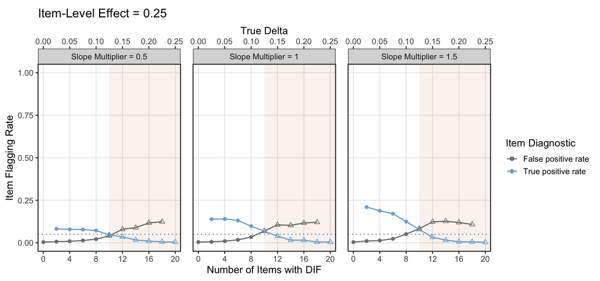

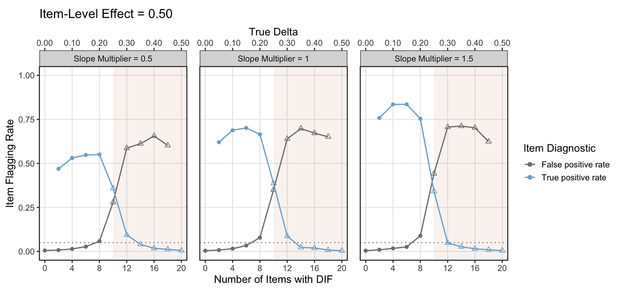

```r
item_diag_plots <- plot_by_effect(item_diag, function(plot_data) {
  ggplot(
    plot_data,
    aes(x = n_dif, y = flagged_rate, color = diagnostic, group = diagnostic,
        shape = p_dif >= 0.5)) +
    geom_rect(
      data = breakdown_band(plot_data),
      aes(xmin = xmin, xmax = xmax, ymin = ymin, ymax = ymax),
      inherit.aes = FALSE,
      fill = "#B85C38",
      alpha = 0.08) +
    geom_hline(yintercept = alpha, linetype = 3, color = "grey50") +
    geom_point(size = 2.1, na.rm = TRUE) +
    geom_line(linewidth = 0.75, na.rm = TRUE) +
    scale_y_continuous(limits = c(0, 1), breaks = seq(0, 1, 0.25)) +
    scale_color_manual(
      values = c("False positive rate" = "grey50",
                 "True positive rate" = "#7BAFD4")) +
    scale_shape_manual(
      values = c("FALSE" = 16, "TRUE" = 2),
      guide = "none") +
    ndif_x_scale(plot_data) +
    coord_cartesian(clip = "off") +
    sim2_public_facets() +
    labs(
      x = "Number of Items with DIF",
      y = "Item Flagging Rate",
      color = "Item Diagnostic") +
    public_plot_theme
})
```

```r
item_weight_summary <- item_diag |>
  select(
    slope_multiplier, target_Delta_i, n_dif, true_dif,
    mean_weight, mean_k) |>
  mutate(item_type = ifelse(true_dif, "True DIF", "True Anchor"))

knitr::kable(item_weight_summary, digits = 3)
```

| slope_multiplier | target_Delta_i | n_dif | true_dif | mean_weight | mean_k | item_type |
| --- | --- | --- | --- | --- | --- | --- |
| 0.5 | Delta_i = .25 | 0 | FALSE | 0.797 | 2.298 | True Anchor |
| 0.5 | Delta_i = .25 | 2 | FALSE | 0.789 | 2.273 | True Anchor |
| 0.5 | Delta_i = .25 | 2 | TRUE | 0.548 | 2.530 | True DIF |
| 0.5 | Delta_i = .25 | 4 | FALSE | 0.782 | 2.255 | True Anchor |
| 0.5 | Delta_i = .25 | 4 | TRUE | 0.566 | 2.472 | True DIF |
| 0.5 | Delta_i = .25 | 6 | TRUE | 0.581 | 2.423 | True DIF |
| 0.5 | Delta_i = .25 | 6 | FALSE | 0.773 | 2.245 | True Anchor |
| 0.5 | Delta_i = .25 | 8 | TRUE | 0.603 | 2.374 | True DIF |
| 0.5 | Delta_i = .25 | 8 | FALSE | 0.756 | 2.248 | True Anchor |
| 0.5 | Delta_i = .25 | 10 | FALSE | 0.712 | 2.285 | True Anchor |
| 0.5 | Delta_i = .25 | 10 | TRUE | 0.652 | 2.311 | True DIF |
| 0.5 | Delta_i = .25 | 12 | TRUE | 0.697 | 2.265 | True DIF |
| 0.5 | Delta_i = .25 | 12 | FALSE | 0.645 | 2.348 | True Anchor |
| 0.5 | Delta_i = .25 | 14 | FALSE | 0.604 | 2.413 | True Anchor |
| 0.5 | Delta_i = .25 | 14 | TRUE | 0.737 | 2.249 | True DIF |
| 0.5 | Delta_i = .25 | 16 | TRUE | 0.770 | 2.250 | True DIF |
| 0.5 | Delta_i = .25 | 16 | FALSE | 0.548 | 2.492 | True Anchor |
| 0.5 | Delta_i = .25 | 18 | TRUE | 0.775 | 2.268 | True DIF |
| 0.5 | Delta_i = .25 | 18 | FALSE | 0.518 | 2.571 | True Anchor |
| 0.5 | Delta_i = .25 | 20 | TRUE | 0.789 | 2.298 | True DIF |
| 0.5 | Delta_i = .50 | 0 | FALSE | 0.794 | 2.298 | True Anchor |
| 0.5 | Delta_i = .50 | 2 | TRUE | 0.196 | 2.793 | True DIF |
| 0.5 | Delta_i = .50 | 2 | FALSE | 0.789 | 2.243 | True Anchor |
| 0.5 | Delta_i = .50 | 4 | FALSE | 0.781 | 2.201 | True Anchor |
| 0.5 | Delta_i = .50 | 4 | TRUE | 0.177 | 2.689 | True DIF |
| 0.5 | Delta_i = .50 | 6 | TRUE | 0.178 | 2.598 | True DIF |
| 0.5 | Delta_i = .50 | 6 | FALSE | 0.762 | 2.170 | True Anchor |
| 0.5 | Delta_i = .50 | 8 | TRUE | 0.212 | 2.500 | True DIF |
| 0.5 | Delta_i = .50 | 8 | FALSE | 0.731 | 2.164 | True Anchor |
| 0.5 | Delta_i = .50 | 10 | FALSE | 0.543 | 2.279 | True Anchor |

[output cut: 90 more lines]

# Supplementary Analysis of Item-Level Variances

This diagnostic isolates the relationship between item discrimination and the standard error of the item-level scaling function. There is no DIF in this supplementary setup: the target item has the same discrimination and intercept in both groups, and the latent distributions are identical. The target item’s discrimination is varied from `a = 0.5` to `a = 2.0` in both groups.

```r
item_variance_diag_file <- file.path(
  results_dir,
  "sim2_item_level_variance_diagnostic.rds")

run_item_level_variance_diagnostic <- function(
  a.grid = seq(0.5, 2, by = 0.1),
  n.reps = 100,
  n.persons = 500,
  n.items = 20,
  focal.item = 1,
  fun = "d_fun3",
  seed = 20260728,
  n.cores = NULL) {

  stopifnot(focal.item >= 1, focal.item <= n.items)
  check_archive_robustDIF()
  if (is.null(n.cores) || is.na(n.cores)) {
    detected.cores <- parallel::detectCores()
    n.cores <- if (is.na(detected.cores)) 1 else max(1, min(10, detected.cores - 2))
  }

  tasks <- expand.grid(
    focal_a = a.grid,
    rep = seq_len(n.reps),
    KEEP.OUT.ATTRS = FALSE)
  tasks$row_id <- seq_len(nrow(tasks))

  base.a <- seq(0.75, 1.75, length.out = n.items)
  base.b <- seq(-1.8, 1.8, length.out = n.items)
  base.b[focal.item] <- 0

  run_task <- function(i) {
    set.seed(seed + tasks$row_id[i])

    a <- base.a
    a[focal.item] <- tasks$focal_a[i]
    d <- -base.b * a

    theta0 <- rnorm(n.persons)
    theta1 <- rnorm(n.persons)
    dat0 <- simdata(a, d, n.persons, "2PL", Theta = matrix(theta0))
    dat1 <- simdata(a, d, n.persons, "2PL", Theta = matrix(theta1))

    out <- tryCatch({
      fit0 <- mirt(dat0, 1, SE = TRUE, verbose = FALSE)
      fit1 <- mirt(dat1, 1, SE = TRUE, verbose = FALSE)
      mle <- robustDIF::get_model_parms(list(fit0, fit1))
      y <- robustDIF::y_fun(mle, fun)
      y.se <- sqrt(Matrix::diag(robustDIF::vcov_y(mle, fun = fun)))

      data.frame(
        focal_a = tasks$focal_a[i],
        rep = tasks$rep[i],
        item = focal.item,
        y_hat = y[focal.item],
        y_se = y.se[focal.item],
        converged_0 = isTRUE(fit0@OptimInfo$converged),
        converged_1 = isTRUE(fit1@OptimInfo$converged),
        error = NA_character_)
    }, error = function(e) {
      data.frame(
        focal_a = tasks$focal_a[i],
        rep = tasks$rep[i],
        item = focal.item,
        y_hat = NA_real_,
        y_se = NA_real_,
        converged_0 = FALSE,
        converged_1 = FALSE,
        error = conditionMessage(e))
    })

    out
  }

  diag_rows <- parallel::mclapply(
    seq_len(nrow(tasks)),
    run_task,
    mc.cores = n.cores,
    mc.set.seed = FALSE)

  bind_rows(diag_rows)
}

if (file.exists(item_variance_diag_file)) {
  item_variance_diag <- readRDS(item_variance_diag_file)
} else {
  item_variance_diag <- run_item_level_variance_diagnostic()
  saveRDS(item_variance_diag, item_variance_diag_file)
}

item_variance_diag_summary <- item_variance_diag |>
  summarize(
    mean_y = mean_or_na(y_hat),
    empirical_sd_y = sd_or_na(y_hat),
    mean_se_y = mean_or_na(y_se),
    q10_se_y = quantile(y_se, 0.10, na.rm = TRUE),
    q90_se_y = quantile(y_se, 0.90, na.rm = TRUE),
    failure_rate = mean(is.na(y_se) | !converged_0 | !converged_1),
    .by = focal_a)

knitr::kable(item_variance_diag_summary, digits = 3)
```

| focal_a | mean_y | empirical_sd_y | mean_se_y | q10_se_y | q90_se_y | failure_rate |
| --- | --- | --- | --- | --- | --- | --- |
| 0.5 | -0.016 | 0.288 | 0.266 | 0.219 | 0.325 | 0 |
| 0.6 | -0.001 | 0.223 | 0.230 | 0.194 | 0.263 | 0 |
| 0.7 | 0.000 | 0.186 | 0.200 | 0.182 | 0.218 | 0 |
| 0.8 | -0.005 | 0.197 | 0.182 | 0.162 | 0.206 | 0 |
| 0.9 | -0.012 | 0.172 | 0.166 | 0.151 | 0.182 | 0 |
| 1.0 | 0.000 | 0.143 | 0.154 | 0.142 | 0.165 | 0 |
| 1.1 | -0.008 | 0.151 | 0.143 | 0.131 | 0.155 | 0 |
| 1.2 | -0.005 | 0.138 | 0.135 | 0.125 | 0.145 | 0 |
| 1.3 | 0.014 | 0.141 | 0.129 | 0.120 | 0.139 | 0 |
| 1.4 | -0.001 | 0.126 | 0.123 | 0.115 | 0.130 | 0 |
| 1.5 | -0.021 | 0.118 | 0.119 | 0.111 | 0.126 | 0 |
| 1.6 | 0.007 | 0.115 | 0.115 | 0.109 | 0.120 | 0 |
| 1.7 | 0.011 | 0.119 | 0.111 | 0.106 | 0.117 | 0 |
| 1.8 | 0.009 | 0.105 | 0.108 | 0.102 | 0.113 | 0 |
| 1.9 | 0.005 | 0.119 | 0.106 | 0.101 | 0.112 | 0 |
| 2.0 | -0.005 | 0.112 | 0.104 | 0.100 | 0.109 | 0 |

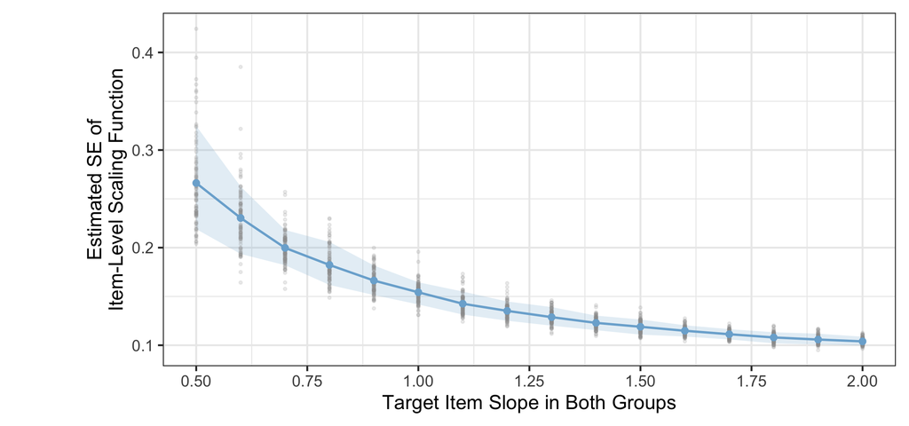

```r
item_variance_plot <- ggplot(
  item_variance_diag_summary,
  aes(x = focal_a, y = mean_se_y)) +
  geom_ribbon(
    aes(ymin = q10_se_y, ymax = q90_se_y),
    fill = "#7BAFD4",
    alpha = 0.20) +
  geom_point(
    data = item_variance_diag,
    aes(x = focal_a, y = y_se),
    inherit.aes = FALSE,
    color = "grey60",
    alpha = 0.16,
    size = 0.8,
    na.rm = TRUE) +
  geom_line(color = "#7BAFD4", linewidth = 1) +
  geom_point(color = "#7BAFD4", size = 2.2) +
  scale_x_continuous(breaks = seq(0.5, 2, by = 0.25)) +
  labs(
    x = "Target Item Slope in Both Groups",
    y = "Estimated SE of\nItem-Level Scaling Function") +
  theme_bw(base_size = 18) +
  theme(plot.margin = margin(t = 12, r = 12, b = 12, l = 80))

item_variance_plot
```

```r
ggsave(
  file.path(figure_dir, "item_level_variance_by_discrimination.png"),
  item_variance_plot,
  width = 8.5,
  height = 5.0,
  dpi = 200)
```

# Bias and Precision

## Scaling Function Bias

This figure parallels the scaling-function bias plot in Simulation 1. `Naive` is the mean of all item-level scaling functions. `RDIF` is the robust estimate of the common-item scaling function, and `True` is the oracle unit-weighted estimate using the known anchor set.

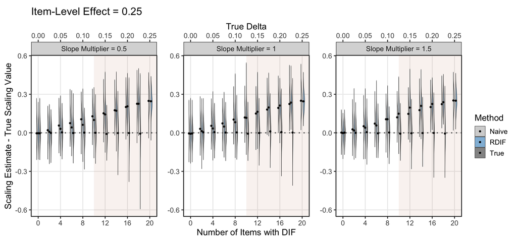

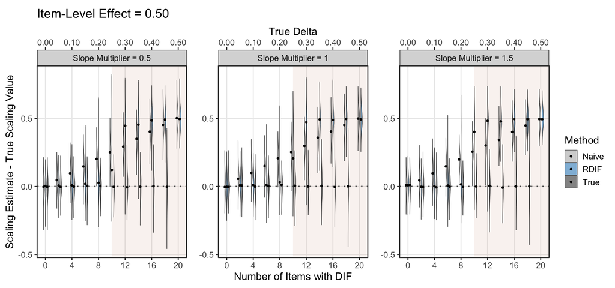

```r
scale_bias <- bind_rows(
  sim_delta |>
    filter(method == "RDIF") |>
    transmute(
      Method = "Naive",
      slope_multiplier,
      slope_cell,
      slope_cell_public,
      target_Delta_i,
      target_Delta_i_num,
      target_Delta_i_public,
      n_dif,
      p_dif,
      true_Delta,
      Bias = naive_est - delta_0),
  sim_delta |>
    transmute(
      Method = as.character(method),
      slope_multiplier,
      slope_cell,
      slope_cell_public,
      target_Delta_i,
      target_Delta_i_num,
      target_Delta_i_public,
      n_dif,
      p_dif,
      true_Delta,
      Bias = scale_est - delta_0)) |>
  mutate(
    Method = factor(
      Method,
      levels = c("Naive", method_levels),
      ordered = TRUE),
    breakdown = p_dif >= 0.5)

scale_cols <- c("Naive" = "grey80", method_cols)

scale_bias_plots <- plot_by_effect(scale_bias, function(plot_data) {
  ggplot(plot_data, aes(x = n_dif, y = Bias, fill = Method)) +
    geom_rect(
      data = breakdown_band(plot_data),
      aes(xmin = xmin, xmax = xmax, ymin = ymin, ymax = ymax),
      inherit.aes = FALSE,
      fill = "#B85C38",
      alpha = 0.08) +
    geom_hline(yintercept = 0, linetype = 3, linewidth = 0.9, color = "grey40") +
    see::geom_violinhalf(
      aes(group = interaction(n_dif, Method)),
      position = position_dodge(width = 0.85),
      trim = TRUE,
      width = 2,
      linewidth = 0.25,
      alpha = 0.85) +
    stat_summary(
      aes(group = interaction(n_dif, Method)),
      fun = median,
      geom = "point",
      position = position_dodge(width = 0.85),
      size = 0.8,
      color = "black") +
    scale_fill_manual(values = scale_cols) +
    ndif_x_scale(plot_data) +
    coord_cartesian(clip = "off") +
    sim2_public_facets(free_y = TRUE) +
    labs(
      x = "Number of Items with DIF",
      y = "Scaling Estimate - True Scaling Value",
      fill = "Method") +
    public_plot_theme
})
```

```r
scale_bias_table <- scale_bias |>
  summarize(
    bias = mean_or_na(Bias),
    .by = c(Method, slope_multiplier, target_Delta_i, n_dif)) |>
  mutate(Method = as.character(Method)) |>
  arrange(slope_multiplier, target_Delta_i, n_dif, Method) |>
  pivot_wider(names_from = Method, values_from = bias)

knitr::kable(scale_bias_table, digits = 3)
```

| slope_multiplier | target_Delta_i | n_dif | Naive | RDIF | True |
| --- | --- | --- | --- | --- | --- |
| 0.5 | Delta_i = .25 | 0 | -0.002 | -0.003 | -0.002 |
| 0.5 | Delta_i = .25 | 2 | 0.020 | 0.006 | -0.004 |
| 0.5 | Delta_i = .25 | 4 | 0.056 | 0.033 | 0.007 |
| 0.5 | Delta_i = .25 | 6 | 0.073 | 0.042 | -0.002 |
| 0.5 | Delta_i = .25 | 8 | 0.101 | 0.065 | -0.001 |
| 0.5 | Delta_i = .25 | 10 | 0.129 | 0.102 | 0.005 |
| 0.5 | Delta_i = .25 | 12 | 0.151 | 0.141 | -0.002 |
| 0.5 | Delta_i = .25 | 14 | 0.177 | 0.172 | -0.003 |
| 0.5 | Delta_i = .25 | 16 | 0.204 | 0.209 | -0.003 |
| 0.5 | Delta_i = .25 | 18 | 0.224 | 0.225 | -0.004 |
| 0.5 | Delta_i = .25 | 20 | 0.252 | 0.246 | NA |
| 0.5 | Delta_i = .50 | 0 | 0.002 | 0.002 | 0.002 |
| 0.5 | Delta_i = .50 | 2 | 0.053 | 0.007 | 0.003 |
| 0.5 | Delta_i = .50 | 4 | 0.099 | 0.010 | -0.003 |
| 0.5 | Delta_i = .50 | 6 | 0.154 | 0.024 | 0.004 |
| 0.5 | Delta_i = .50 | 8 | 0.200 | 0.046 | -0.003 |
| 0.5 | Delta_i = .50 | 10 | 0.249 | 0.195 | -0.003 |
| 0.5 | Delta_i = .50 | 12 | 0.297 | 0.403 | -0.001 |
| 0.5 | Delta_i = .50 | 14 | 0.347 | 0.446 | -0.004 |
| 0.5 | Delta_i = .50 | 16 | 0.407 | 0.489 | 0.000 |
| 0.5 | Delta_i = .50 | 18 | 0.457 | 0.490 | -0.007 |
| 0.5 | Delta_i = .50 | 20 | 0.504 | 0.497 | NA |
| 1.0 | Delta_i = .25 | 0 | -0.003 | -0.004 | -0.003 |
| 1.0 | Delta_i = .25 | 2 | 0.027 | 0.016 | 0.002 |
| 1.0 | Delta_i = .25 | 4 | 0.057 | 0.036 | 0.008 |
| 1.0 | Delta_i = .25 | 6 | 0.073 | 0.049 | -0.003 |
| 1.0 | Delta_i = .25 | 8 | 0.103 | 0.087 | 0.004 |
| 1.0 | Delta_i = .25 | 10 | 0.122 | 0.121 | -0.005 |
| 1.0 | Delta_i = .25 | 12 | 0.151 | 0.165 | -0.001 |
| 1.0 | Delta_i = .25 | 14 | 0.182 | 0.200 | 0.010 |
| 1.0 | Delta_i = .25 | 16 | 0.198 | 0.212 | 0.003 |
| 1.0 | Delta_i = .25 | 18 | 0.226 | 0.237 | 0.001 |
| 1.0 | Delta_i = .25 | 20 | 0.248 | 0.245 | NA |
| 1.0 | Delta_i = .50 | 0 | -0.002 | -0.001 | -0.002 |
| 1.0 | Delta_i = .50 | 2 | 0.056 | 0.009 | 0.006 |
| 1.0 | Delta_i = .50 | 4 | 0.100 | 0.008 | 0.001 |
| 1.0 | Delta_i = .50 | 6 | 0.149 | 0.015 | 0.000 |
| 1.0 | Delta_i = .50 | 8 | 0.206 | 0.060 | 0.006 |
| 1.0 | Delta_i = .50 | 10 | 0.254 | 0.242 | 0.003 |
| 1.0 | Delta_i = .50 | 12 | 0.301 | 0.436 | 0.002 |
| 1.0 | Delta_i = .50 | 14 | 0.356 | 0.490 | 0.007 |
| 1.0 | Delta_i = .50 | 16 | 0.402 | 0.488 | 0.003 |
| 1.0 | Delta_i = .50 | 18 | 0.454 | 0.496 | 0.000 |
| 1.0 | Delta_i = .50 | 20 | 0.499 | 0.496 | NA |
| 1.5 | Delta_i = .25 | 0 | 0.000 | 0.000 | 0.000 |
| 1.5 | Delta_i = .25 | 2 | 0.025 | 0.017 | 0.000 |
| 1.5 | Delta_i = .25 | 4 | 0.049 | 0.037 | 0.001 |
| 1.5 | Delta_i = .25 | 6 | 0.070 | 0.061 | -0.005 |
| 1.5 | Delta_i = .25 | 8 | 0.100 | 0.105 | 0.000 |
| 1.5 | Delta_i = .25 | 10 | 0.120 | 0.144 | -0.006 |
| 1.5 | Delta_i = .25 | 12 | 0.151 | 0.192 | -0.004 |
| 1.5 | Delta_i = .25 | 14 | 0.176 | 0.212 | 0.003 |
| 1.5 | Delta_i = .25 | 16 | 0.203 | 0.228 | 0.003 |
| 1.5 | Delta_i = .25 | 18 | 0.228 | 0.242 | 0.001 |
| 1.5 | Delta_i = .25 | 20 | 0.252 | 0.253 | NA |
| 1.5 | Delta_i = .50 | 0 | 0.004 | 0.004 | 0.004 |
| 1.5 | Delta_i = .50 | 2 | 0.047 | -0.002 | -0.003 |
| 1.5 | Delta_i = .50 | 4 | 0.100 | 0.004 | -0.001 |
| 1.5 | Delta_i = .50 | 6 | 0.148 | 0.007 | -0.003 |
| 1.5 | Delta_i = .50 | 8 | 0.197 | 0.055 | -0.003 |
| 1.5 | Delta_i = .50 | 10 | 0.254 | 0.302 | 0.005 |
| 1.5 | Delta_i = .50 | 12 | 0.300 | 0.470 | 0.000 |
| 1.5 | Delta_i = .50 | 14 | 0.344 | 0.483 | -0.009 |
| 1.5 | Delta_i = .50 | 16 | 0.402 | 0.497 | 0.001 |
| 1.5 | Delta_i = .50 | 18 | 0.447 | 0.493 | -0.002 |
| 1.5 | Delta_i = .50 | 20 | 0.498 | 0.497 | NA |

## DTF Effect Bias

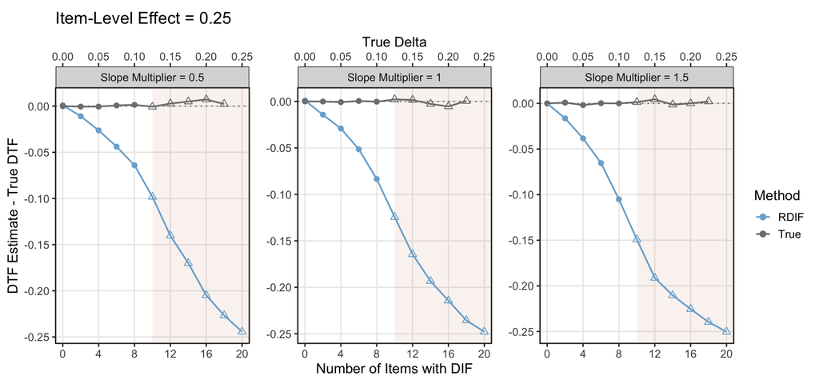

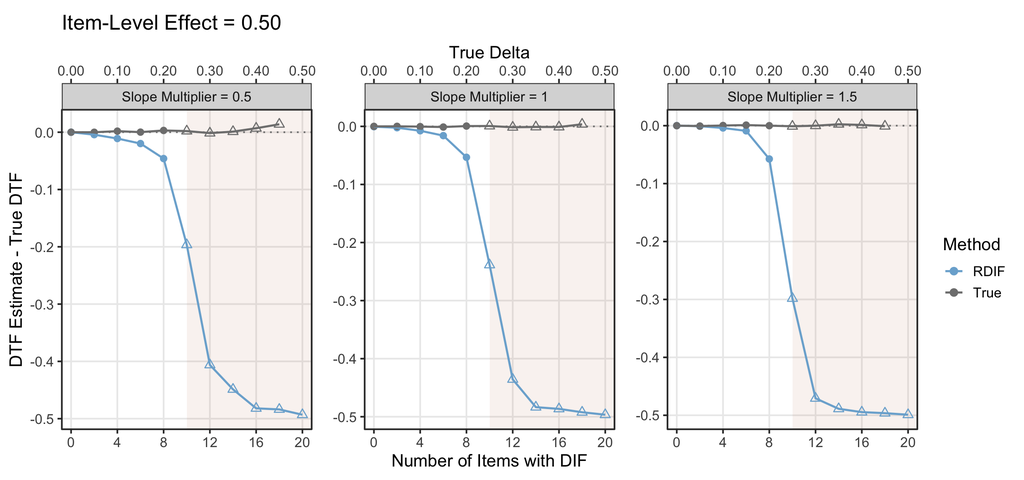

```r
delta_bias <- sim_delta |>
  mutate(Bias = delta_hat - true_Delta) |>
  summarize(
    bias = mean_or_na(Bias),
    true_Delta = mean_or_na(true_Delta),
    .by = c(
      method, slope_multiplier, slope_cell, slope_cell_public,
      target_Delta_i, target_Delta_i_num, target_Delta_i_public, n_dif, p_dif))

delta_bias_plots <- plot_by_effect(delta_bias, function(plot_data) {
  ggplot(plot_data, aes(x = n_dif, y = bias, color = method, group = method,
                        shape = p_dif >= 0.5)) +
    geom_rect(
      data = breakdown_band(plot_data),
      aes(xmin = xmin, xmax = xmax, ymin = ymin, ymax = ymax),
      inherit.aes = FALSE,
      fill = "#B85C38",
      alpha = 0.08) +
    geom_hline(yintercept = 0, linetype = 3, color = "grey50") +
    geom_point(size = 2.4, na.rm = TRUE) +
    geom_line(linewidth = 0.8, na.rm = TRUE) +
    scale_color_manual(values = method_cols, drop = FALSE) +
    scale_shape_manual(
      values = c("FALSE" = 16, "TRUE" = 2),
      guide = "none") +
    ndif_x_scale(plot_data) +
    coord_cartesian(clip = "off") +
    sim2_public_facets(free_y = TRUE) +
    labs(
      x = "Number of Items with DIF",
      y = "DTF Estimate - True DTF",
      color = "Method") +
    public_plot_theme
})
```

```r
delta_bias_wide <- delta_bias |>
  mutate(method = as.character(method)) |>
  arrange(slope_multiplier, target_Delta_i, n_dif, method) |>
  select(method, slope_multiplier, target_Delta_i, n_dif, bias) |>
  pivot_wider(names_from = method, values_from = bias)

knitr::kable(delta_bias_wide, digits = 3)
```

| slope_multiplier | target_Delta_i | n_dif | RDIF | True |
| --- | --- | --- | --- | --- |
| 0.5 | Delta_i = .25 | 0 | 0.001 | 0.000 |
| 0.5 | Delta_i = .25 | 2 | -0.011 | -0.001 |
| 0.5 | Delta_i = .25 | 4 | -0.026 | 0.000 |
| 0.5 | Delta_i = .25 | 6 | -0.044 | 0.001 |
| 0.5 | Delta_i = .25 | 8 | -0.064 | 0.001 |
| 0.5 | Delta_i = .25 | 10 | -0.098 | -0.001 |
| 0.5 | Delta_i = .25 | 12 | -0.140 | 0.003 |
| 0.5 | Delta_i = .25 | 14 | -0.170 | 0.005 |
| 0.5 | Delta_i = .25 | 16 | -0.205 | 0.007 |
| 0.5 | Delta_i = .25 | 18 | -0.227 | 0.002 |
| 0.5 | Delta_i = .25 | 20 | -0.244 | NA |
| 0.5 | Delta_i = .50 | 0 | 0.000 | 0.000 |
| 0.5 | Delta_i = .50 | 2 | -0.004 | 0.000 |
| 0.5 | Delta_i = .50 | 4 | -0.011 | 0.002 |
| 0.5 | Delta_i = .50 | 6 | -0.020 | 0.000 |
| 0.5 | Delta_i = .50 | 8 | -0.046 | 0.003 |
| 0.5 | Delta_i = .50 | 10 | -0.197 | 0.002 |
| 0.5 | Delta_i = .50 | 12 | -0.406 | -0.002 |
| 0.5 | Delta_i = .50 | 14 | -0.449 | 0.001 |
| 0.5 | Delta_i = .50 | 16 | -0.482 | 0.007 |
| 0.5 | Delta_i = .50 | 18 | -0.484 | 0.014 |
| 0.5 | Delta_i = .50 | 20 | -0.493 | NA |
| 1.0 | Delta_i = .25 | 0 | 0.001 | 0.000 |
| 1.0 | Delta_i = .25 | 2 | -0.014 | 0.000 |
| 1.0 | Delta_i = .25 | 4 | -0.029 | -0.001 |
| 1.0 | Delta_i = .25 | 6 | -0.051 | 0.000 |
| 1.0 | Delta_i = .25 | 8 | -0.083 | 0.000 |
| 1.0 | Delta_i = .25 | 10 | -0.124 | 0.002 |
| 1.0 | Delta_i = .25 | 12 | -0.164 | 0.002 |
| 1.0 | Delta_i = .25 | 14 | -0.193 | -0.003 |
| 1.0 | Delta_i = .25 | 16 | -0.214 | -0.005 |
| 1.0 | Delta_i = .25 | 18 | -0.236 | 0.000 |
| 1.0 | Delta_i = .25 | 20 | -0.248 | NA |
| 1.0 | Delta_i = .50 | 0 | -0.001 | 0.000 |
| 1.0 | Delta_i = .50 | 2 | -0.002 | 0.000 |
| 1.0 | Delta_i = .50 | 4 | -0.008 | 0.000 |
| 1.0 | Delta_i = .50 | 6 | -0.016 | -0.001 |
| 1.0 | Delta_i = .50 | 8 | -0.053 | 0.001 |
| 1.0 | Delta_i = .50 | 10 | -0.239 | 0.001 |
| 1.0 | Delta_i = .50 | 12 | -0.436 | -0.002 |
| 1.0 | Delta_i = .50 | 14 | -0.484 | -0.001 |
| 1.0 | Delta_i = .50 | 16 | -0.486 | -0.001 |
| 1.0 | Delta_i = .50 | 18 | -0.492 | 0.004 |
| 1.0 | Delta_i = .50 | 20 | -0.497 | NA |
| 1.5 | Delta_i = .25 | 0 | 0.000 | 0.000 |
| 1.5 | Delta_i = .25 | 2 | -0.016 | 0.001 |
| 1.5 | Delta_i = .25 | 4 | -0.038 | -0.002 |
| 1.5 | Delta_i = .25 | 6 | -0.065 | 0.000 |
| 1.5 | Delta_i = .25 | 8 | -0.105 | 0.000 |
| 1.5 | Delta_i = .25 | 10 | -0.149 | 0.001 |
| 1.5 | Delta_i = .25 | 12 | -0.191 | 0.004 |
| 1.5 | Delta_i = .25 | 14 | -0.210 | -0.001 |
| 1.5 | Delta_i = .25 | 16 | -0.225 | 0.000 |
| 1.5 | Delta_i = .25 | 18 | -0.240 | 0.002 |
| 1.5 | Delta_i = .25 | 20 | -0.250 | NA |
| 1.5 | Delta_i = .50 | 0 | 0.000 | 0.000 |
| 1.5 | Delta_i = .50 | 2 | -0.001 | -0.001 |
| 1.5 | Delta_i = .50 | 4 | -0.004 | 0.000 |
| 1.5 | Delta_i = .50 | 6 | -0.009 | 0.001 |
| 1.5 | Delta_i = .50 | 8 | -0.057 | 0.000 |
| 1.5 | Delta_i = .50 | 10 | -0.298 | -0.001 |
| 1.5 | Delta_i = .50 | 12 | -0.471 | 0.000 |
| 1.5 | Delta_i = .50 | 14 | -0.489 | 0.002 |
| 1.5 | Delta_i = .50 | 16 | -0.495 | 0.001 |
| 1.5 | Delta_i = .50 | 18 | -0.496 | -0.001 |
| 1.5 | Delta_i = .50 | 20 | -0.499 | NA |

# Rejection Rates

```r
sim_power <- sim_delta |>
  summarize(
    rejection_rate = mean_or_na(as.numeric(rejected)),
    true_Delta = mean_or_na(true_Delta),
    .by = c(
      method, slope_multiplier, slope_cell, slope_cell_public,
      target_Delta_i, target_Delta_i_num, target_Delta_i_public,
      n_dif, p_dif, n_items)) |>
  mutate(
    rejection_rate = ifelse(
      method == "True" & n_dif == n_items,
      NA_real_,
      rejection_rate))
```

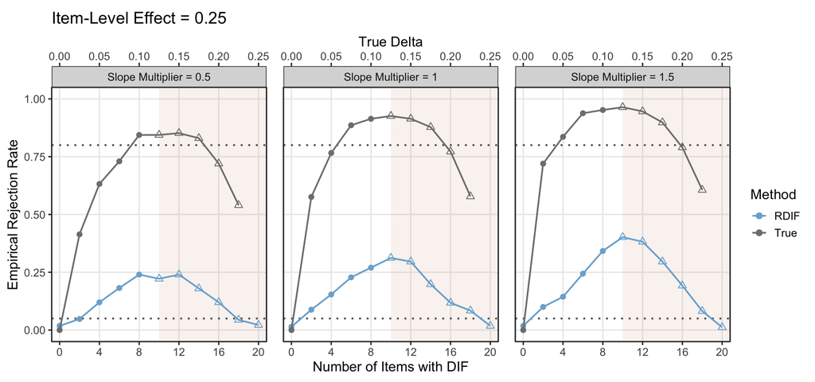

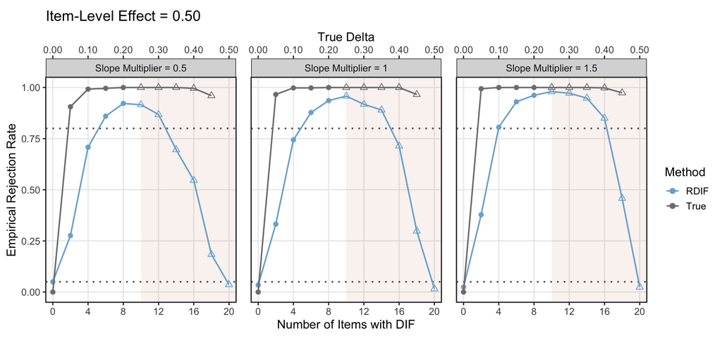

```r
rejection_plots <- plot_by_effect(
  sim_power,
  function(plot_data) {
    ggplot(
      plot_data,
      aes(x = n_dif, y = rejection_rate, color = method, group = method,
          shape = p_dif >= 0.5)) +
      geom_rect(
        data = breakdown_band(plot_data),
        aes(xmin = xmin, xmax = xmax, ymin = ymin, ymax = ymax),
        inherit.aes = FALSE,
        fill = "#B85C38",
        alpha = 0.08) +
      geom_hline(yintercept = alpha, linetype = 3, linewidth = 0.9, color = "grey40") +
      geom_hline(yintercept = 0.80, linetype = 3, linewidth = 0.9, color = "grey40") +
      geom_point(size = 2.4, na.rm = TRUE) +
      geom_line(linewidth = 0.8, na.rm = TRUE) +
      scale_y_continuous(limits = c(0, 1), breaks = seq(0, 1, .25)) +
      scale_color_manual(values = method_cols, drop = FALSE) +
      scale_shape_manual(
        values = c("FALSE" = 16, "TRUE" = 2),
        guide = "none") +
      ndif_x_scale(plot_data) +
      coord_cartesian(clip = "off") +
      sim2_public_facets() +
      labs(
        x = "Number of Items with DIF",
        y = "Empirical Rejection Rate",
        color = "Method") +
      public_plot_theme
  },
  file_prefix = "rejection_rates_by_true_delta")
```

```r
sim_power_wide <- sim_power |>
  select(method, slope_multiplier, target_Delta_i, n_dif, true_Delta,
         rejection_rate) |>
  pivot_wider(names_from = method, values_from = rejection_rate)

knitr::kable(sim_power_wide, digits = 3)
```

| slope_multiplier | target_Delta_i | n_dif | true_Delta | RDIF | True |
| --- | --- | --- | --- | --- | --- |
| 0.5 | Delta_i = .25 | 0 | 0.000 | 0.018 | 0.000 |
| 0.5 | Delta_i = .25 | 2 | 0.025 | 0.048 | 0.414 |
| 0.5 | Delta_i = .25 | 4 | 0.050 | 0.120 | 0.632 |
| 0.5 | Delta_i = .25 | 6 | 0.075 | 0.182 | 0.730 |
| 0.5 | Delta_i = .25 | 8 | 0.100 | 0.240 | 0.844 |
| 0.5 | Delta_i = .25 | 10 | 0.125 | 0.222 | 0.844 |
| 0.5 | Delta_i = .25 | 12 | 0.150 | 0.240 | 0.852 |
| 0.5 | Delta_i = .25 | 14 | 0.175 | 0.180 | 0.830 |
| 0.5 | Delta_i = .25 | 16 | 0.200 | 0.120 | 0.720 |
| 0.5 | Delta_i = .25 | 18 | 0.225 | 0.044 | 0.540 |
| 0.5 | Delta_i = .25 | 20 | 0.250 | 0.022 | NA |
| 0.5 | Delta_i = .50 | 0 | 0.000 | 0.050 | 0.000 |
| 0.5 | Delta_i = .50 | 2 | 0.050 | 0.276 | 0.906 |
| 0.5 | Delta_i = .50 | 4 | 0.100 | 0.708 | 0.992 |
| 0.5 | Delta_i = .50 | 6 | 0.150 | 0.860 | 0.996 |
| 0.5 | Delta_i = .50 | 8 | 0.200 | 0.922 | 1.000 |
| 0.5 | Delta_i = .50 | 10 | 0.250 | 0.916 | 1.000 |
| 0.5 | Delta_i = .50 | 12 | 0.300 | 0.868 | 1.000 |
| 0.5 | Delta_i = .50 | 14 | 0.350 | 0.696 | 1.000 |
| 0.5 | Delta_i = .50 | 16 | 0.400 | 0.546 | 0.996 |
| 0.5 | Delta_i = .50 | 18 | 0.450 | 0.184 | 0.960 |
| 0.5 | Delta_i = .50 | 20 | 0.500 | 0.036 | NA |
| 1.0 | Delta_i = .25 | 0 | 0.000 | 0.014 | 0.000 |
| 1.0 | Delta_i = .25 | 2 | 0.025 | 0.088 | 0.576 |
| 1.0 | Delta_i = .25 | 4 | 0.050 | 0.154 | 0.766 |
| 1.0 | Delta_i = .25 | 6 | 0.075 | 0.228 | 0.886 |
| 1.0 | Delta_i = .25 | 8 | 0.100 | 0.270 | 0.914 |
| 1.0 | Delta_i = .25 | 10 | 0.125 | 0.312 | 0.926 |
| 1.0 | Delta_i = .25 | 12 | 0.150 | 0.296 | 0.914 |
| 1.0 | Delta_i = .25 | 14 | 0.175 | 0.198 | 0.878 |
| 1.0 | Delta_i = .25 | 16 | 0.200 | 0.118 | 0.772 |
| 1.0 | Delta_i = .25 | 18 | 0.225 | 0.084 | 0.578 |
| 1.0 | Delta_i = .25 | 20 | 0.250 | 0.018 | NA |
| 1.0 | Delta_i = .50 | 0 | 0.000 | 0.034 | 0.000 |
| 1.0 | Delta_i = .50 | 2 | 0.050 | 0.332 | 0.966 |
| 1.0 | Delta_i = .50 | 4 | 0.100 | 0.744 | 0.998 |
| 1.0 | Delta_i = .50 | 6 | 0.150 | 0.878 | 0.998 |
| 1.0 | Delta_i = .50 | 8 | 0.200 | 0.936 | 1.000 |
| 1.0 | Delta_i = .50 | 10 | 0.250 | 0.958 | 1.000 |
| 1.0 | Delta_i = .50 | 12 | 0.300 | 0.918 | 1.000 |
| 1.0 | Delta_i = .50 | 14 | 0.350 | 0.890 | 1.000 |
| 1.0 | Delta_i = .50 | 16 | 0.400 | 0.714 | 1.000 |
| 1.0 | Delta_i = .50 | 18 | 0.450 | 0.298 | 0.966 |
| 1.0 | Delta_i = .50 | 20 | 0.500 | 0.016 | NA |
| 1.5 | Delta_i = .25 | 0 | 0.000 | 0.018 | 0.000 |
| 1.5 | Delta_i = .25 | 2 | 0.025 | 0.100 | 0.720 |
| 1.5 | Delta_i = .25 | 4 | 0.050 | 0.144 | 0.836 |
| 1.5 | Delta_i = .25 | 6 | 0.075 | 0.244 | 0.938 |
| 1.5 | Delta_i = .25 | 8 | 0.100 | 0.342 | 0.952 |
| 1.5 | Delta_i = .25 | 10 | 0.125 | 0.402 | 0.964 |
| 1.5 | Delta_i = .25 | 12 | 0.150 | 0.382 | 0.946 |
| 1.5 | Delta_i = .25 | 14 | 0.175 | 0.296 | 0.898 |
| 1.5 | Delta_i = .25 | 16 | 0.200 | 0.192 | 0.790 |
| 1.5 | Delta_i = .25 | 18 | 0.225 | 0.082 | 0.606 |
| 1.5 | Delta_i = .25 | 20 | 0.250 | 0.012 | NA |
| 1.5 | Delta_i = .50 | 0 | 0.000 | 0.024 | 0.000 |
| 1.5 | Delta_i = .50 | 2 | 0.050 | 0.378 | 0.994 |
| 1.5 | Delta_i = .50 | 4 | 0.100 | 0.806 | 1.000 |
| 1.5 | Delta_i = .50 | 6 | 0.150 | 0.930 | 1.000 |
| 1.5 | Delta_i = .50 | 8 | 0.200 | 0.962 | 1.000 |
| 1.5 | Delta_i = .50 | 10 | 0.250 | 0.980 | 1.000 |
| 1.5 | Delta_i = .50 | 12 | 0.300 | 0.972 | 1.000 |
| 1.5 | Delta_i = .50 | 14 | 0.350 | 0.948 | 1.000 |
| 1.5 | Delta_i = .50 | 16 | 0.400 | 0.850 | 0.998 |
| 1.5 | Delta_i = .50 | 18 | 0.450 | 0.458 | 0.974 |
| 1.5 | Delta_i = .50 | 20 | 0.500 | 0.024 | NA |

# Coverage

Coverage is based on the stored indicator from `data_sim2_target_delta()`, which checks whether the nominal 95% Wald interval for `delta_hat` contains the true DTF value, `true_Delta`.

```r
sim_coverage <- sim_delta |>
  summarize(
    coverage = mean_or_na(as.numeric(covered)),
    mean_width = mean_or_na(2 * qnorm(.975) * delta_se),
    mean_se = mean_or_na(delta_se),
    true_Delta = mean_or_na(true_Delta),
    .by = c(
      method, slope_multiplier, slope_cell, slope_cell_public,
      target_Delta_i, target_Delta_i_num, target_Delta_i_public, n_dif, p_dif))
```

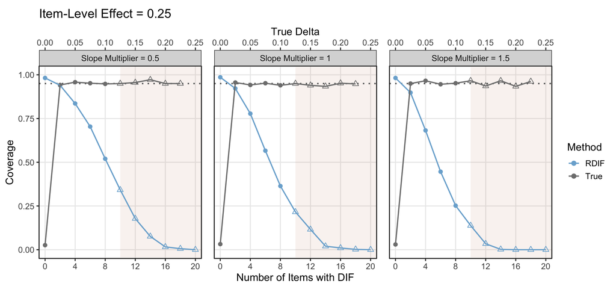

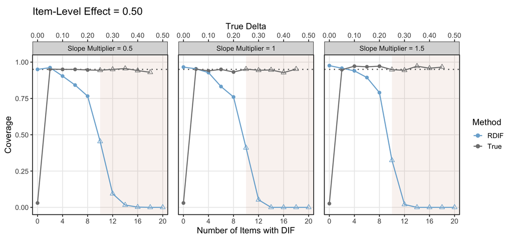

```r
coverage_plots <- plot_by_effect(
  sim_coverage,
  function(plot_data) {
    ggplot(
      plot_data,
      aes(x = n_dif, y = coverage, color = method, group = method,
          shape = p_dif >= 0.5)) +
      geom_rect(
        data = breakdown_band(plot_data),
        aes(xmin = xmin, xmax = xmax, ymin = ymin, ymax = ymax),
        inherit.aes = FALSE,
        fill = "#B85C38",
        alpha = 0.08) +
      geom_hline(yintercept = 0.95, linetype = 3, linewidth = 0.9, color = "grey40") +
      geom_point(size = 2.4, na.rm = TRUE) +
      geom_line(linewidth = 0.8, na.rm = TRUE) +
      scale_y_continuous(limits = c(0, 1), breaks = seq(0, 1, .25)) +
      scale_color_manual(values = method_cols, drop = FALSE) +
      scale_shape_manual(
        values = c("FALSE" = 16, "TRUE" = 2),
        guide = "none") +
      ndif_x_scale(plot_data) +
      coord_cartesian(clip = "off") +
      sim2_public_facets() +
      labs(
        x = "Number of Items with DIF",
        y = "Coverage",
        color = "Method") +
      public_plot_theme
  },
  file_prefix = "coverage_by_true_delta")
```

```r
sim_coverage_wide <- sim_coverage |>
  select(method, slope_multiplier, target_Delta_i, n_dif, coverage) |>
  pivot_wider(names_from = method, values_from = coverage)

knitr::kable(sim_coverage_wide, digits = 3)
```

| slope_multiplier | target_Delta_i | n_dif | RDIF | True |
| --- | --- | --- | --- | --- |
| 0.5 | Delta_i = .25 | 0 | 0.982 | 0.026 |
| 0.5 | Delta_i = .25 | 2 | 0.940 | 0.942 |
| 0.5 | Delta_i = .25 | 4 | 0.836 | 0.958 |
| 0.5 | Delta_i = .25 | 6 | 0.704 | 0.952 |
| 0.5 | Delta_i = .25 | 8 | 0.520 | 0.948 |
| 0.5 | Delta_i = .25 | 10 | 0.342 | 0.950 |
| 0.5 | Delta_i = .25 | 12 | 0.178 | 0.956 |
| 0.5 | Delta_i = .25 | 14 | 0.076 | 0.972 |
| 0.5 | Delta_i = .25 | 16 | 0.016 | 0.950 |
| 0.5 | Delta_i = .25 | 18 | 0.006 | 0.950 |
| 0.5 | Delta_i = .25 | 20 | 0.000 | NA |
| 0.5 | Delta_i = .50 | 0 | 0.950 | 0.030 |
| 0.5 | Delta_i = .50 | 2 | 0.962 | 0.952 |
| 0.5 | Delta_i = .50 | 4 | 0.904 | 0.950 |
| 0.5 | Delta_i = .50 | 6 | 0.842 | 0.950 |
| 0.5 | Delta_i = .50 | 8 | 0.766 | 0.946 |
| 0.5 | Delta_i = .50 | 10 | 0.454 | 0.944 |
| 0.5 | Delta_i = .50 | 12 | 0.094 | 0.950 |
| 0.5 | Delta_i = .50 | 14 | 0.016 | 0.956 |
| 0.5 | Delta_i = .50 | 16 | 0.002 | 0.942 |
| 0.5 | Delta_i = .50 | 18 | 0.000 | 0.930 |
| 0.5 | Delta_i = .50 | 20 | 0.000 | NA |
| 1.0 | Delta_i = .25 | 0 | 0.986 | 0.032 |
| 1.0 | Delta_i = .25 | 2 | 0.922 | 0.956 |
| 1.0 | Delta_i = .25 | 4 | 0.778 | 0.942 |
| 1.0 | Delta_i = .25 | 6 | 0.566 | 0.952 |
| 1.0 | Delta_i = .25 | 8 | 0.364 | 0.940 |
| 1.0 | Delta_i = .25 | 10 | 0.216 | 0.950 |
| 1.0 | Delta_i = .25 | 12 | 0.116 | 0.940 |
| 1.0 | Delta_i = .25 | 14 | 0.020 | 0.934 |
| 1.0 | Delta_i = .25 | 16 | 0.010 | 0.952 |
| 1.0 | Delta_i = .25 | 18 | 0.002 | 0.948 |
| 1.0 | Delta_i = .25 | 20 | 0.000 | NA |
| 1.0 | Delta_i = .50 | 0 | 0.966 | 0.030 |
| 1.0 | Delta_i = .50 | 2 | 0.954 | 0.952 |
| 1.0 | Delta_i = .50 | 4 | 0.928 | 0.940 |
| 1.0 | Delta_i = .50 | 6 | 0.832 | 0.950 |
| 1.0 | Delta_i = .50 | 8 | 0.760 | 0.932 |
| 1.0 | Delta_i = .50 | 10 | 0.410 | 0.952 |
| 1.0 | Delta_i = .50 | 12 | 0.052 | 0.944 |
| 1.0 | Delta_i = .50 | 14 | 0.000 | 0.946 |
| 1.0 | Delta_i = .50 | 16 | 0.000 | 0.928 |
| 1.0 | Delta_i = .50 | 18 | 0.000 | 0.952 |
| 1.0 | Delta_i = .50 | 20 | 0.000 | NA |
| 1.5 | Delta_i = .25 | 0 | 0.982 | 0.030 |
| 1.5 | Delta_i = .25 | 2 | 0.898 | 0.950 |
| 1.5 | Delta_i = .25 | 4 | 0.682 | 0.966 |
| 1.5 | Delta_i = .25 | 6 | 0.446 | 0.946 |
| 1.5 | Delta_i = .25 | 8 | 0.252 | 0.952 |
| 1.5 | Delta_i = .25 | 10 | 0.138 | 0.966 |
| 1.5 | Delta_i = .25 | 12 | 0.034 | 0.936 |
| 1.5 | Delta_i = .25 | 14 | 0.002 | 0.966 |
| 1.5 | Delta_i = .25 | 16 | 0.000 | 0.934 |
| 1.5 | Delta_i = .25 | 18 | 0.000 | 0.962 |
| 1.5 | Delta_i = .25 | 20 | 0.000 | NA |
| 1.5 | Delta_i = .50 | 0 | 0.976 | 0.026 |
| 1.5 | Delta_i = .50 | 2 | 0.958 | 0.948 |
| 1.5 | Delta_i = .50 | 4 | 0.940 | 0.972 |
| 1.5 | Delta_i = .50 | 6 | 0.894 | 0.968 |
| 1.5 | Delta_i = .50 | 8 | 0.790 | 0.972 |
| 1.5 | Delta_i = .50 | 10 | 0.324 | 0.948 |
| 1.5 | Delta_i = .50 | 12 | 0.020 | 0.944 |
| 1.5 | Delta_i = .50 | 14 | 0.000 | 0.972 |
| 1.5 | Delta_i = .50 | 16 | 0.000 | 0.958 |
| 1.5 | Delta_i = .50 | 18 | 0.000 | 0.966 |
| 1.5 | Delta_i = .50 | 20 | 0.000 | NA |